# Отчет по лабораторной работе № 4

## Настройка виртуального хостинга для HTTP-сервера

На виртуальной машине client убедимся в корректном доступе к веб-серверам (рис. 29 - рис. 30).

## Настройка виртуального хостинга для HTTP-сервера

[figure not shown]

Рисунок 29: Проверка доступа к веб-серверу

## Настройка виртуального хостинга для HTTP-сервера

[figure not shown]

Рисунок 30: Проверка доступа к веб-серверу

## Внесение изменений в настройки внутреннего окружения виртуальной машины

На виртуальной машине server перейдём в каталог для внесения изменений в настройки внутреннего окружения /vagrant/provision/server/, создадим в нём каталог http, в который поместим в соответствующие подкаталоги конфигурационные файлы HTTP-сервера. Теперь заменим конфигурационные файлы DNS-сервера. В каталоге /vagrant/provision/server создадим исполняемый файл http.sh (рис. 31).

## Внесение изменений в настройки внутреннего окружения виртуальной машины

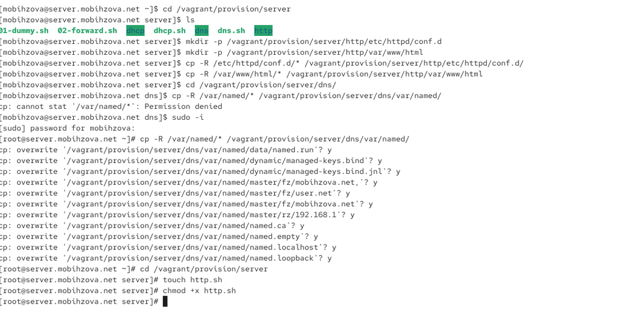

Рисунок 31: Открытие на виртуальной машине server каталога для внесения изменений в настройки внутреннего окружения, создание в нём каталога http. Замена конфигурационных файлов DNS-сервера и создание исполняемого файла http.sh.

## Внесение изменений в настройки внутреннего окружения виртуальной машины

Откроем созданный файл на редактирование и пропишем в нём скрипт (рис. 32)

## Внесение изменений в настройки внутреннего окружения виртуальной машины

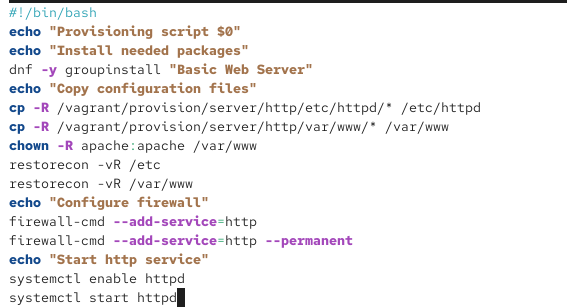

Рисунок 32: Открытие созданного файла на редактирование и прописывание скрипта

## Внесение изменений в настройки внутреннего окружения виртуальной машины

Для отработки созданного скрипта во время загрузки виртуальных машин в конфигурационном файле Vagrantfile добавим в конфигурации сервера следующую запись (рис. 33)

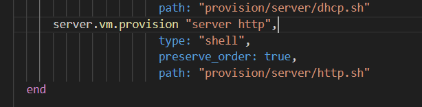

Рисунок 33: Добавление записи для отработки созданного скрипта во время загрузки виртуальных машин.

## Выводы

В ходе выполнения лабораторной работы были приобретены практические навыки по установке и базовому конфигурированию HTTP-сервера Apache.